# Część metodologiczna

Zuzanna Mróz, Aleksander Podsiad, Michał Wdowski

# 1 Introduction

Sprawozdanie to skoncentruje się na odtwarzalności sześciu różnych artykułów, z czego pierwsze trzy są nieco powiązane ze sobą.

O ile nie określono inaczej (lub nie pojawił się po nich komunikat o błędzie), przedstawione wyniki należy traktować jako identyczne z tymi, które podano w artykule. Należy też zauważyć, że w jakiś sposób wszystkie badane w tym raporcie pakiety okazały się być nadal utrzymane i dostępne dla obecnej (3.6.3) wersji R.

# 2 [The *ade4* Package: Implementing the Duality Diagram for Ecologists](https://www.jstatsoft.org/article/view/v022i04)

Cytat z abstraktu artykułu:

“Analizy wielowymiarowe są dobrze znane i szeroko stosowane do identyfikacji i zrozumienia struktur społeczności ekologicznych. Pakiet ade4 dla środowiska statystycznego R proponuje dużą liczbę metod wieloczynnikowych. Jego wdrożenie jest zgodne z tradycją francuskiej szkoły”Analyse des Donn´ees" i opiera się na wykorzystaniu diagramu dwoistości".

Poniżej znajdują się wyniki przykładowego kodu z gazety.

```r
###################################################
### chunk number 5: ni1
###################################################
library(ade4)
apropos("dudi.")
```

```
##  [1] "dudi.acm"       "dudi.coa"       "dudi.dec"       "dudi.fca"
##  [5] "dudi.fpca"      "dudi.hillsmith" "dudi.mix"       "dudi.nsc"
##  [9] "dudi.pca"       "dudi.pco"       "dudi.type"
```

```r
###################################################
### chunk number 6: ni2
###################################################
args(as.dudi)
```

```
## function (df, col.w, row.w, scannf, nf, call, type, tol = 1e-07,
##     full = FALSE)
## NULL
```

```r
###################################################
### chunk number 7: ni3
###################################################
methods(class="dudi")
```

```
##  [1] [         bca       biplot    inertia   predict   print     scatter
##  [8] screeplot summary   supcol    suprow    t         wca
## see '?methods' for accessing help and source code
```

```r
###################################################
### chunk number 8: ex1
###################################################
data(dunedata)
sapply(dunedata$envir,class)
```

```
## $A1
## [1] "numeric"
##
## $moisture
## [1] "integer"
##
## $manure
## [1] "integer"
##
## $use
## [1] "ordered" "factor"
##
## $management
## [1] "factor"
```

```r
###################################################
### chunk number 9: ex2
###################################################
dunedata$envir$use <- factor(dunedata$envir$use,ordered=FALSE)
summary(dunedata$envir)
```

```
##        A1            moisture       manure           use    management
##  Min.   : 2.800   Min.   :1.0   Min.   :0.00   hayfield:7   BF:3
##  1st Qu.: 3.500   1st Qu.:1.0   1st Qu.:0.00   both    :8   HF:5
##  Median : 4.200   Median :2.0   Median :2.00   grazing :5   NM:6
##  Mean   : 4.850   Mean   :2.9   Mean   :1.75                SF:6
##  3rd Qu.: 5.725   3rd Qu.:5.0   3rd Qu.:3.00
##  Max.   :11.500   Max.   :5.0   Max.   :4.00
```

```r
###################################################
### chunk number 10: ex3
###################################################
dd1 <- dudi.hillsmith(dunedata$envir, scannf = FALSE,nf=2)
dd1
```

```
## Duality diagramm
## class: mix dudi
## $call: dudi.hillsmith(df = dunedata$envir, scannf = FALSE, nf = 2)
##
## $nf: 2 axis-components saved
## $rank: 8
## eigen values: 2.542 1.858 1.231 0.9899 0.6927 ...
##   vector length mode    content
## 1 $cw    10     numeric column weights
## 2 $lw    20     numeric row weights
## 3 $eig   8      numeric eigen values
##
##   data.frame nrow ncol content
## 1 $tab       20   10   modified array
## 2 $li        20   2    row coordinates
## 3 $l1        20   2    row normed scores
## 4 $co        10   2    column coordinates
## 5 $c1        10   2    column normed scores
## other elements: assign index cr center norm
```

W tym kawałku wyniki są prawie identyczne, z wyjątkiem ostatniego rzędu: “inne elementy: przypisać normę środkową indeksu cr” zamiast “inne elementy: przypisać indeks cr”, cokolwiek to znaczy.

```r
###################################################
### chunk number 11: ex4
###################################################
scatter.dudi(dd1)
```

```
## Error in scatter.dudi(dd1): could not find function "scatter.dudi"
```

I tu mamy pierwszy błąd. Jak zauważono wcześniej, skrócono nazwy niektórych metod, np. “scatter.dudi”. W obecnym pakiecie nazywa się to po prostu “scatter()”.

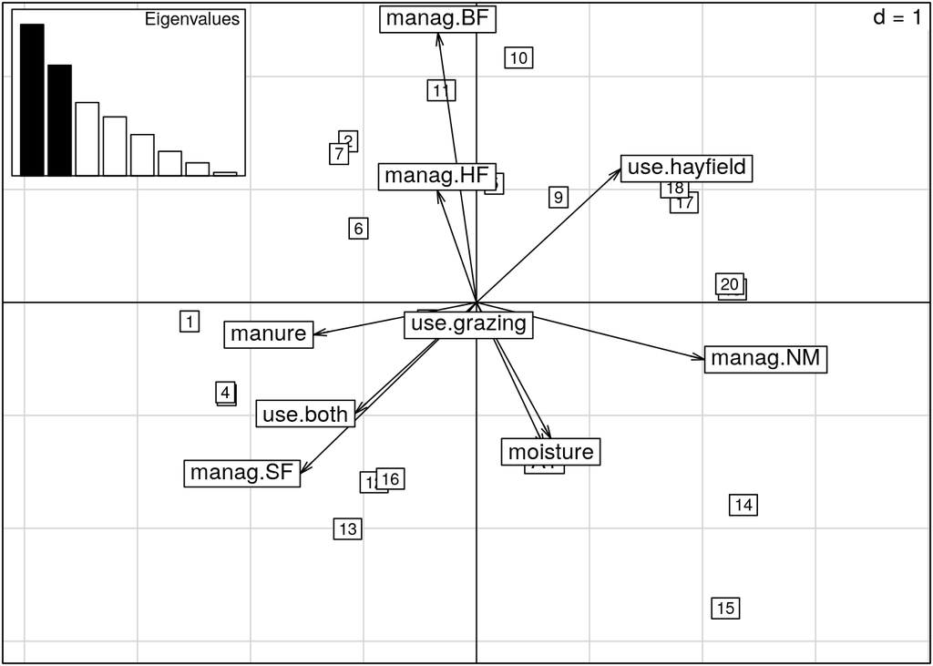

```r
scatter(dd1)
```

Po wywołaniu prawidłowej nazwy metody komunikat o błędzie zniknie. Rysowany wykres nie jest jednak taki sam jak w artykule. Wykresy słupkowe w rogu są identyczne, ale z jakiegoś powodu wykres w tle jest odwróconą wersją wykresu przedstawionego w artykule.

Można powiedzieć, że artykuł jest na ogół powtarzalny

# 3 [*untb*, an R Package For Simulating Ecological Drift Under the Unified Neutral Theory of Biodiversity](https://www.jstatsoft.org/article/view/v022i12)

Zgodnie z cytatem z abstraktu:

„Rozkład liczebności wśród gatunków o podobnych stylach życia jest klasycznym problemem w ekologii.

Zunifikowana neutralna teoria bioróżnorodności (…) stwierdza, że obserwowaną dynamikę populacji można wyjaśnić przy założeniu równoważności liczby osób na mieszkańca. Można zatem zrezygnować z różnic między gatunkami oraz różnic między licznymi i rzadkimi gatunkami: wszystkie osobniki zachowują się jednakowo pod względem prawdopodobieństwa rozmnażania i śmierci.

Jest (…) faktem, że taka oszczędna teoria skutkuje nietrywialną krzywą różnorodności dominacji (to znaczy jednoczesnym istnieniem zarówno gatunków obfitych, jak i rzadkich) i (…) teoria przewiduje krzywe liczności pasujące do siebie obserwacje w szerokim zakresie ekologii.

(…) Pakiet untb [składa się z] procedur R do numerycznej symulacji dryfu ekologicznego w ramach zunifikowanej teorii neutralnej. Pakiet narzędzi wizualizacyjnych, analitycznych i symulacyjnych znajduje się w pakiecie (…). ”

```r
###################################################
### chunk number 3: SaundersSummary
###################################################
data(saunders)
summary(saunders.tot)
```

```
## Number of individuals: 8419
## Number of species: 176
## Number of singletons: 42
## Most abundant species: Ventojassa (1046 individuals)
## estimated theta:  31.35894
```

```r
###################################################
### chunk number 4: prestonSaunders
###################################################
preston(saunders.tot,n=9)
```

```
##                   1   2  3-4  5-8  9-16  17-32  33-64  65-128  129-Inf
## number of species 42 14   21   22    13     20     15      11       18
```

```r
###################################################
### chunk number 5: prestonSaundersTemp
###################################################
jj.preston <- preston(saunders.tot)
jj.summary <- summary(saunders.tot)
```

```r
###################################################
### chunk number 6: calculate_uncertainty_Saunders
###################################################
n <- 10
J <- no.of.ind(saunders.tot)
unc <- list()
theta_hat <- optimal.theta(saunders.tot)
for(i in 1:n){
  unc[[i]] <- rand.neutral(J=J, theta=theta_hat)
}
```

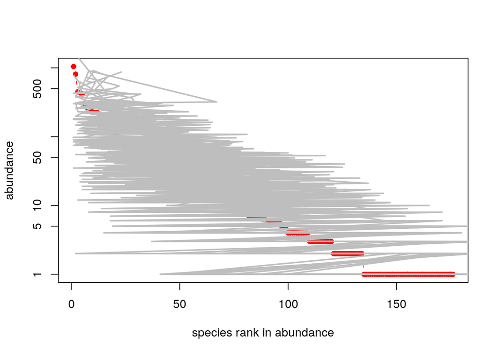

```r
###################################################
### chunk number 7: plotSaunders
###################################################
plot(saunders.tot,uncertainty=FALSE)
for(i in 1:n){
  points(unc[[i]],type="l",col="grey")
}
```

Jak można się domyślić, powyższy wykres znacznie różni się od tego w artykule. Jest on całkowicie nieczytelny. Jest to również pierwsza rozbieżność z wynikami przedstawionymi w artykule.

```r
###################################################
### chunk number 8: optimalThetaSaunders
###################################################
optimal.theta(saunders.tot)
```

```
## [1] 31.35894
```

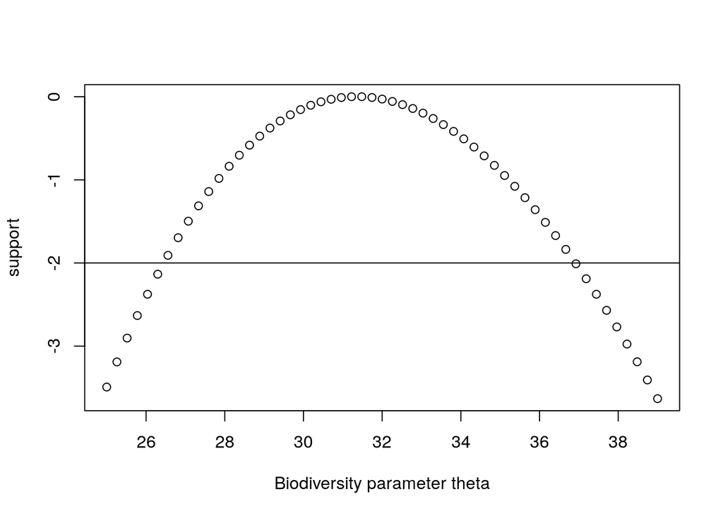

```r
###################################################
### chunk number 9: supportTheta
###################################################
S <- no.of.spp(saunders.tot)
J <- no.of.ind(saunders.tot)
theta <- seq(from=25,to=39,len=55)
jj <- theta.likelihood(theta=theta,S=S,J=J,give.log=TRUE)
support <- jj-max(jj)
plot(theta,support,xlab=paste("Biodiversity parameter",expression(theta)),ylab="support")
abline(h= -2)
```

```r
###################################################
### chunk number 10:
###################################################
load("bci1982.Rdata")
```

```
## Error in readChar(con, 5L, useBytes = TRUE): cannot open the connection
```

Podany w artykule [link](http://ctfs.si.edu/datasets/bci) do powyższego zbioru danych nie prowadzi do niczego. Krótkie wyszukiwanie w google nie pomogło w jego zlokalizowaniu. Możliwe że przepadł na zawsze. Z tego powodu większość poniższych fragmentów prowadzi do błędów.

```r
###################################################
### chunk number 11: optimal.params
###################################################
op.bci.1982 <- optimal.params(bci1982, l)
```

```
## Error in optimal.params(bci1982, l): object 'l' not found
```

```r
###################################################
### chunk number 12: flish2
###################################################
op.bci.1982
```

```
## Error in eval(expr, envir, enclos): object 'op.bci.1982' not found
```

```r
###################################################
### chunk number 13: estimateMandTheta
###################################################
load("mle.Rdata")
```

```
## Error in readChar(con, 5L, useBytes = TRUE): cannot open the connection
```

```r
plot(x100,log="xy",xlim=c(1,80),ylim=c(0.001,1),col="black",pch=1,
main=paste("Maximum likelihood estimates of ", expression(m), " and ",expression(theta))
     )
```

```
## Error in plot(x100, log = "xy", xlim = c(1, 80), ylim = c(0.001, 1), col = "black", : object 'x100' not found
```

```r
points(x1000,col="red",pch=2)
```

```
## Error in points(x1000, col = "red", pch = 2): object 'x1000' not found
```

```r
points(x10000,col="blue",pch=3)
```

```
## Error in points(x10000, col = "blue", pch = 3): object 'x10000' not found
```

```r
points(50,0.01,pch=4,lwd=3,cex=2)
```

```
## Error in plot.xy(xy.coords(x, y), type = type, ...): plot.new has not been called yet
```

```r
legend( "bottomleft", c("100","1000","10000"),col=c("black","red","blue"), pch=1:3, title="Local community size")
```

```
## Error in strwidth(legend, units = "user", cex = cex, font = text.font): plot.new has not been called yet
```

```r
###################################################
### chunk number 14: e.lowandhigh
###################################################
n <- 20
x <- expected.abundance(J=n, theta=3)
e.low  <- expected.abundance(J=n,theta=4)
e.high <- expected.abundance(J=n,theta=2)
```

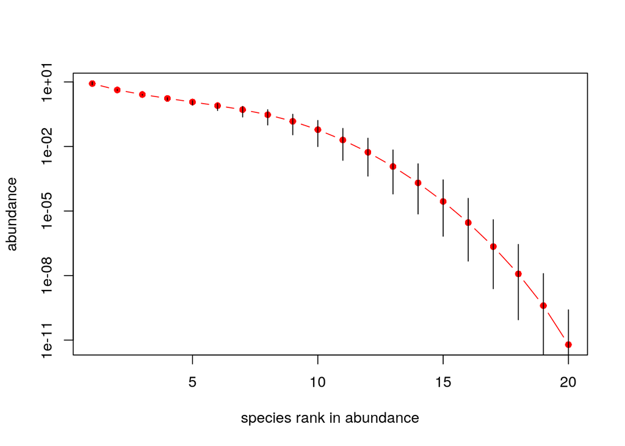

```r
###################################################
### chunk number 15: expectedAbundance
###################################################
plot(x)
segments(x0=1:n,x1=1:n,y0=e.low,y1=e.high)
```

Powyższy wykres nie wykorzystuje brakującego zestawu danych i tym samym pozostaje wierny temu, który został przedstawiony w artykule.

```r
###################################################
### chunk number 16: calculate_thirdRank
###################################################
rank3 <- table(replicate(1000,rand.neutral(J=20,theta=2)[3]))
```

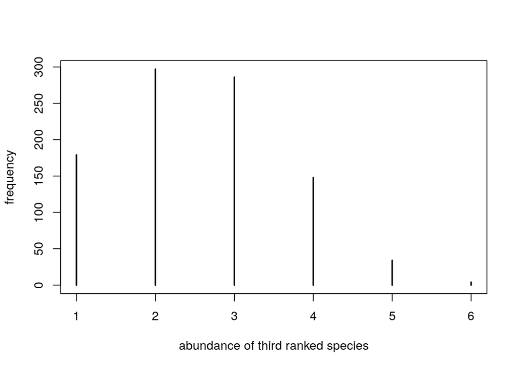

```r
###################################################
### chunk number 17: plot_thirdRank
###################################################
plot(rank3,xlab="abundance of third ranked species",ylab="frequency")
```

Tak samo jak powyżej.

```r
###################################################
### chunk number 18: calculate_species_table
###################################################
 {
set.seed(0);
a <- species.table(untb(start=rep(1,60),prob=0.002, gens=40000,keep=TRUE))
}
```

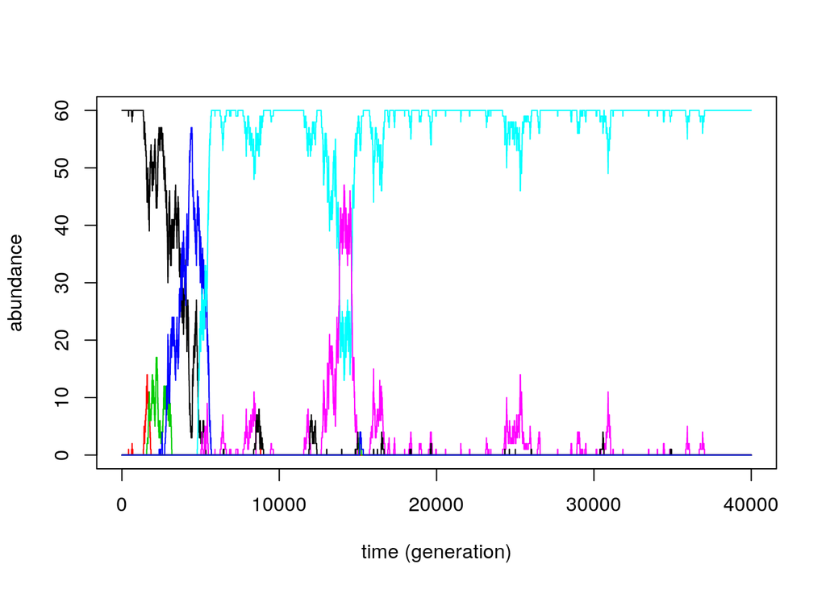

```r
###################################################
### chunk number 19: matplot_species_table
###################################################
matplot(a,type="l",lty=1,xlab="time (generation)",ylab="abundance")
```

W przeciwieństwie do dwóch powyższych wykresów, o ile ten może być jeszcze wygenerowany, to znacznie różni się od wyniku pokazanego w artykule.

```r
###################################################
### chunk number 20: SampleTenThousand
###################################################
set.seed(0)
rn <- rand.neutral(5e6, theta=50)
jj <- isolate(rn,size=10000)
a <- untb(start=jj, prob=0.01, D=10000, gens=1000, meta=rn)
a.logkda <- logkda(a)
```

```r
op <- optimal.params(a,log.kda=a.logkda)
```

```
## Error in optimal.params(a, log.kda = a.logkda): object 'a.logkda' not found
```

```r
v.opt <- volkov(no.of.ind(a), op, bins=TRUE)
```

```
## Error in volkov(no.of.ind(a), op, bins = TRUE): object 'op' not found
```

```r
v.true <- volkov(no.of.ind(a), c(100,0.01), bins=TRUE)
```

```r
###################################################
### chunk number 21: PlotSampleTenThousand
###################################################
pa <- preston(a,n=12)
```

```
## Error in preston(a, n = 12): object 'outnames' not found
```

```r
pa.names <- sub(" ", "", names(pa))
jj <- plot(pa,ylim=c(0,27),axisnames=FALSE,
ylab="Number of species",xlab="Abundance class")
axis(1, at=jj, labels=FALSE, lty=0)
text(jj, par("usr")[3]-0.65, srt=90, cex=0.8, adj=1, labels=pa.names,xpd=TRUE)

points(jj, v.opt[1:12], type="b",col="red",pch=1)
```

```
## Error in xy.coords(x, y): object 'v.opt' not found
```

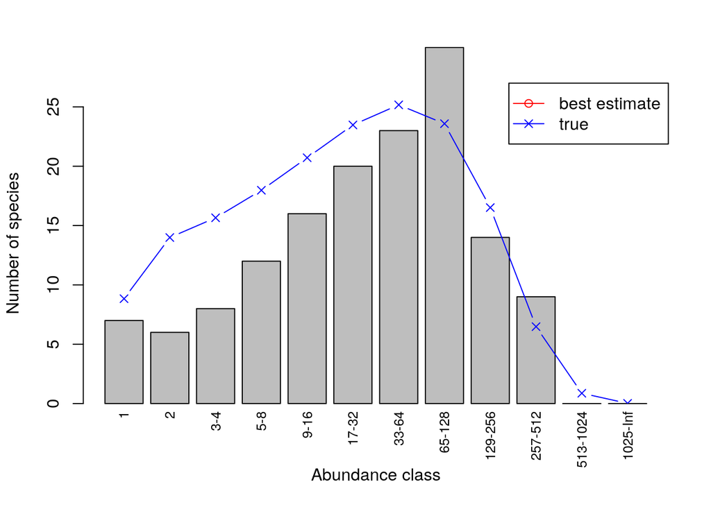

```r
points(jj, v.true[1:12], type="b",col="blue",pch=4)
par(xpd=2)
legend("topright", c("best estimate","true"), pch=c(1,4), col=c("red","blue"), lty=c(1,1))
```

Wykres jest prawie identyczny, ale z powodu problemów z “optimal.params” brakuje na nim linii “best estimate”.

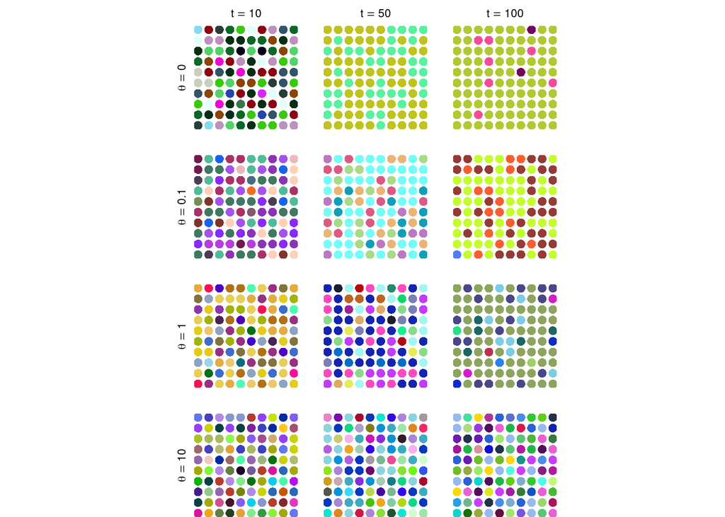

```r
###################################################
### chunk number 22: differentThetas
###################################################
set.seed(0)
f <- function(gens,p){
  display.untb(start=sample(as.census(untb(start=1:100,gens=gens,D=100,prob=p))),gens=0,main="",cex=1.7, asp=1)
}

g <- function(u="title", ...){
  par(srt=0)
  par(mai=c(0,0,0,0))
  plot.new()
  text(0.5,0.5,u,...)
}

h <- function(u="title", ...){
  par(mai=c(0,0,0,0))
  par(srt=90)
  plot.new()
  text(0.5,0.5,u, ...)
}

nf <- layout(matrix(
                    c(00,01,00,02,00,03,
                      04,05,00,06,00,07,
                      00,00,00,00,00,00,
                      08,09,00,10,00,11,
                      00,00,00,00,00,00,
                      12,13,00,14,00,15,
                      00,00,00,00,00,00,
                      16,17,00,18,00,19),8,6,byrow=TRUE),
             c(1,4, 1,4, 1,4),
             c(1,4, 1,4, 1,4, 1,4),
             TRUE)

g(expression(t==10))
g(expression(t==50))
g(expression(t==100))

h(expression(theta==0))
f(10,0)
f(50,0)
f(100,0)
h(expression(theta==0.1))
f(10,0.001)
f(50,0.001)
f(100,0.001)
h(expression(theta==1))
f(10,0.01)
f(50,0.01)
f(100,0.01)
h(expression(theta==10))
f(10,0.1)
f(50,0.1)
f(100,0.1)
```

Ten wykres, choć na pierwszy rzut oka wydaje się podobny, jest zupełnie inny.

Podobnie jak wcześniejszy pakiet, *untb* jest również nadal utrzymany. Oryginalny artykuł z 2007 roku jest o wiele mniej powtarzalny niż ten opisujący *ade4*. Mniej niż połowa wykresów jest możliwa do odtworzenia. W sumie artykuł jest w większości nie do odtworzenia.

# 4 [The *bio.infer* R Package: Maximum Likelihood Method for Predicting Environmental Conditions from Assemblage Composition](https://www.jstatsoft.org/article/view/v022i03)

Cytowane z artykułu: “(…) Pakiet R bio.infer [jest] zestawem skryptów ułatwiających wykorzystanie metod maksymalnego prawdopodobieństwa (ML) do przewidywania warunków środowiskowych. (…) Warunki środowiskowe można często wywnioskować wyłącznie na podstawie danych biologicznych, a wnioski te są przydatne, gdy dostępne są inne źródła danych. Metody prognozowania ML są statystycznie rygorystyczne i mają zastosowanie do szerszego zestawu problemów niż powszechnie stosowane techniki uśredniania ważonego. Metody ML wymagają jednak znacznie większego nakładu czasu na programowanie algorytmów i wykonywanie obliczeń. Pakiet ten został opracowany w celu zmniejszenia nakładu pracy potrzebnego do zastosowania metod predykcji ML”

```r
# Merge EMAP biological data with standardized taxonomy
library(bio.infer)
options(width = 60)
data(itis.ttable)
data(bcnt.emapw)
bcnt.tax <- get.taxonomic(bcnt.emapw, itis.ttable,
                          outputFile = "sum.tax.table.txt")
```

```
## Error in get.taxonomic(bcnt.emapw, itis.ttable, outputFile = "sum.tax.table.txt"): unused arguments (itis.ttable, outputFile = "sum.tax.table.txt")
```

Podczas gdy pierwszy kawałek powodujący komunikat o błędzie może wydawać się zniechęcający, jest on stosunkowo łatwy do rozwiązania. Jak stwierdzono wcześniej, wszystkie pakiety są utrzymywane i od 2007 roku były wielokrotnie aktualizowane. Metoda “get.taxonomic” została uproszczona i obecnie nie wymaga dwóch ostatnich argumentów.

```r
bcnt.tax <- get.taxonomic(bcnt.emapw)
```

```r
# Show excerpt from full taxonomic table
df1 <- read.delim("sum.tax.table.txt")
incvec <- df1[, "FAMILY"] == "EPHEMERIDAE"
incvec[is.na(incvec)] <- F
print(df1[incvec,c("ORDER", "FAMILY", "GENUS", "SPECIES", "TAXANAME")])
```

```
## Error in `[.data.frame`(df1, incvec, c("ORDER", "FAMILY", "GENUS", "SPECIES", : undefined columns selected
```

Kolejny błąd: ten spowodowany zmianą kolumny “TAXANAME” na “taxaname.orig”.

```r
print(df1[incvec,c("ORDER", "FAMILY", "GENUS", "SPECIES", "taxaname.orig")])
```

```
## [1] ORDER         FAMILY        GENUS         SPECIES       taxaname.orig
## <0 rows> (or 0-length row.names)
```

```r
# compute taxon-environment relationships for EMAP species data only
data(envdata.emapw)
coef <- taxon.env(form = ~STRMTEMP + STRMTEMP^2, bcnt = bcnt.tax,
                  envdata = envdata.emapw, bcnt.siteid = "ID.NEW",
                  bcnt.abndid = "ABUND", env.siteid = "ID.NEW",
                  tlevs = "SPECIES", dumpdata = TRUE)
```

```
## Model formula:  resp ~STRMTEMP+I(STRMTEMP^2)
## Minimum number of occurrences:  30
## Warning: glm.fit: fitted probabilities numerically 0 or 1 occurred
##  for DESPAXIA.AUGUSTA
## Warning: glm.fit: fitted probabilities numerically 0 or 1 occurred
##  for DRUNELLA.COLORADENSIS
## Warning: glm.fit: fitted probabilities numerically 0 or 1 occurred
##  for MOSELIA.INFUSCATA
## Number of taxa modeled:
##   TAXON.LEVEL NUM.MODS
## 1     SPECIES       59
```

Wyniki w artykule to “64”, a nie “59”.

```r
# Echo names of coefficient data
names(coef)
```

```
## [1] "tnames"   "csave"    "xvar"     "xlims"    "form"     "roc"
## [7] "raw.data"
```

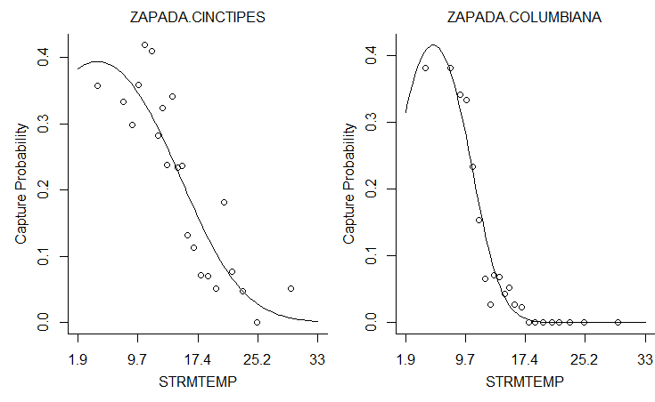

```r
# View taxon-environment relationships
view.te(coef,plotform = "windows")
```

# 5 [The *pls* Package: Principal Component and Partial Least Squares Regression in R](https://www.jstatsoft.org/article/view/v018i02)

## 5.1 Opis

Z abstraktu artykułu: “Pakiet pls implementuje regresję głównych składników (PCR) i częściową regresję najmniejszych kwadratów (PLSR) w R. (…) Kontrola wizualna i ocena jest ważna w chemometrii, a pakiet pls posiada szereg funkcji wykresów punktacji, obciążeń, przewidywań, współczynników i szacunków RMSEP.”

Poniżej znajdują się wyniki przykładowego kodu z artykułu.

## 5.2 Reprodukcja

```r
###################################################
library("pls")
```

```r
###################################################
data("yarn")
data("oliveoil")
data("gasoline")
```

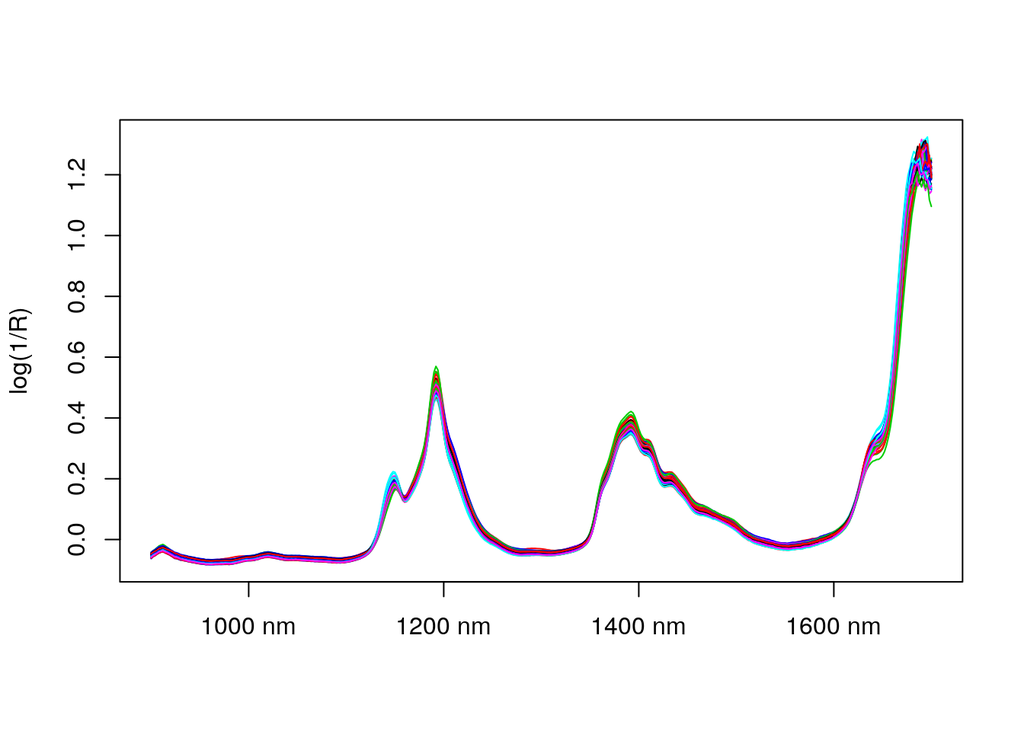

```r
###################################################
matplot(t(gasoline$NIR), type = "l", lty = 1, ylab = "log(1/R)", xaxt = "n")
ind <- pretty(seq(from = 900, to = 1700, by = 2))
ind <- ind[ind >= 900 & ind <= 1700]
ind <- (ind - 898) / 2
axis(1, ind, colnames(gasoline$NIR)[ind])
```

```r
###################################################
gasTrain <- gasoline[1:50,]
gasTest <- gasoline[51:60,]
```

```r
###################################################
gas1 <- plsr(octane ~ NIR, ncomp = 10, data = gasTrain, validation = "LOO")
```

```r
###################################################
summary(gas1)
```

```
## Data:    X dimension: 50 401
##  Y dimension: 50 1
## Fit method: kernelpls
## Number of components considered: 10
##
## VALIDATION: RMSEP
## Cross-validated using 50 leave-one-out segments.
##        (Intercept)  1 comps  2 comps  3 comps  4 comps  5 comps  6 comps
## CV           1.545    1.357   0.2966   0.2524   0.2476   0.2398   0.2319
## adjCV        1.545    1.356   0.2947   0.2521   0.2478   0.2388   0.2313
##        7 comps  8 comps  9 comps  10 comps
## CV      0.2386   0.2316   0.2449    0.2673
## adjCV   0.2377   0.2308   0.2438    0.2657
##
## TRAINING: % variance explained
##         1 comps  2 comps  3 comps  4 comps  5 comps  6 comps  7 comps
## X         78.17    85.58    93.41    96.06    96.94    97.89    98.38
## octane    29.39    96.85    97.89    98.26    98.86    98.96    99.09
##         8 comps  9 comps  10 comps
## X         98.85    99.02     99.19
## octane    99.16    99.28     99.39
```

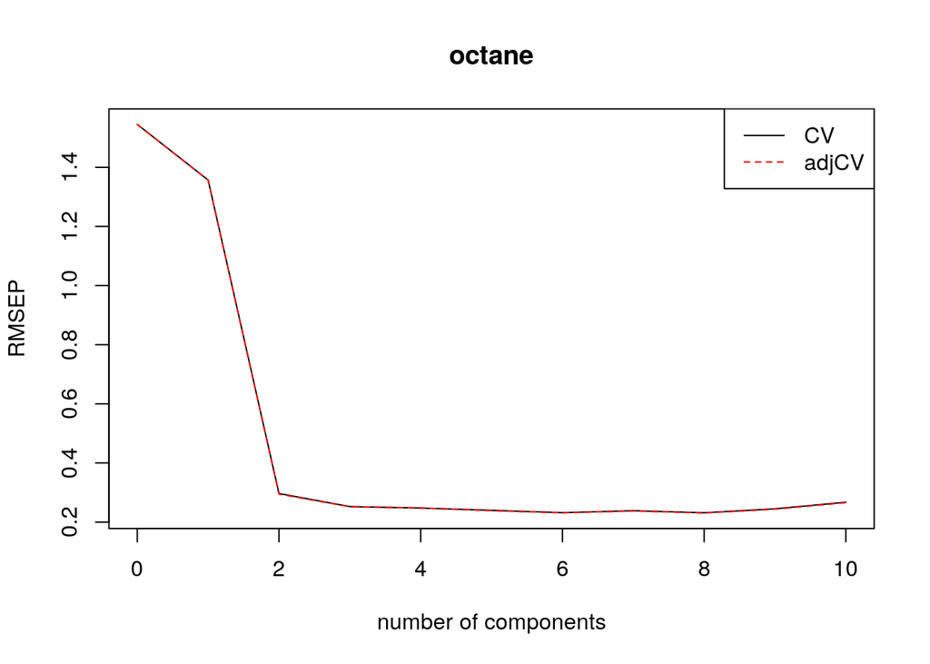

```r
###################################################
plot(RMSEP(gas1), legendpos = "topright")
```

Zarówno wykres powyżej jak i 2 dalsze wykresy wydają się za to identyczne.

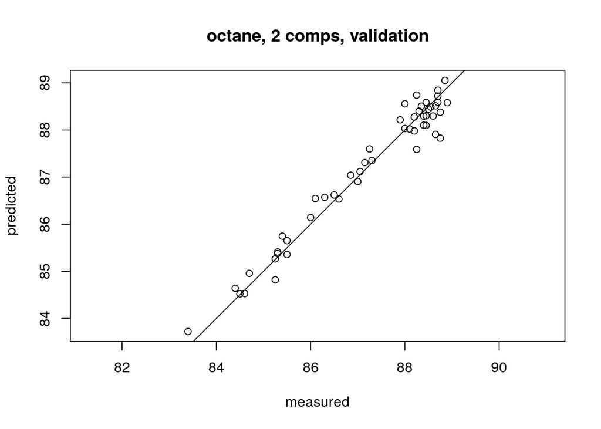

```r
###################################################
plot(gas1, ncomp = 2, asp = 1, line = TRUE)
```

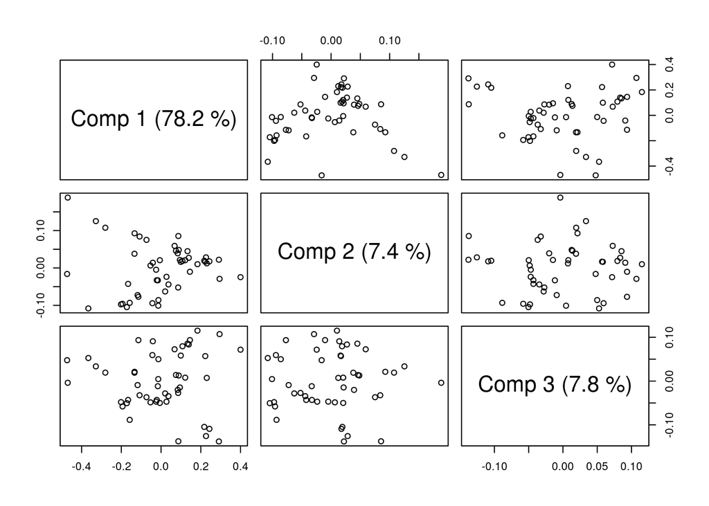

```r
###################################################
plot(gas1, plottype = "scores", comps = 1:3)
```

```r
###################################################
explvar(gas1)
```

```
##     Comp 1     Comp 2     Comp 3     Comp 4     Comp 5     Comp 6
## 78.1707683  7.4122245  7.8241556  2.6577773  0.8768214  0.9466384
##     Comp 7     Comp 8     Comp 9    Comp 10
##  0.4921537  0.4723207  0.1688272  0.1693770
```

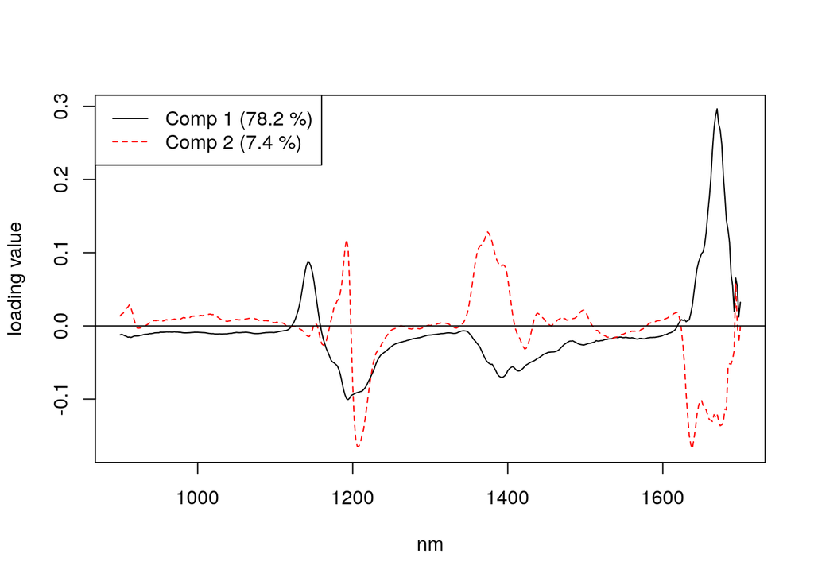

```r
###################################################
plot(gas1, "loadings", comps = 1:2, legendpos = "topleft", labels = "numbers", xlab = "nm")
abline(h = 0)
```

```r
###################################################
predict(gas1, ncomp = 2, newdata = gasTest)
```

```
## , , 2 comps
##
##      octane
## 51 87.94125
## 52 87.25242
## 53 88.15832
## 54 84.96913
## 55 85.15396
## 56 84.51415
## 57 87.56190
## 58 86.84622
## 59 89.18925
## 60 87.09116
```

Podobnie jak wyżej: tutaj 5 miejsc po przecinku, w artykule 2.

```r
###################################################
RMSEP(gas1, newdata = gasTest)
```

```
## (Intercept)      1 comps      2 comps      3 comps      4 comps
##      1.5369       1.1696       0.2445       0.2341       0.3287
##     5 comps      6 comps      7 comps      8 comps      9 comps
##      0.2780       0.2703       0.3301       0.3571       0.4090
##    10 comps
##      0.6116
```

```r
###################################################
dens1 <- plsr(density ~ NIR, ncomp = 5, data = yarn)
```

```r
###################################################
dim(oliveoil$sensory)
```

```
## [1] 16  6
```

```r
plsr(sensory ~ chemical, data = oliveoil)
```

```
## Partial least squares regression , fitted with the kernel algorithm.
## Call:
## plsr(formula = sensory ~ chemical, data = oliveoil)
```

```r
###################################################
trainind <- which(yarn$train == TRUE)
dens2 <- update(dens1, subset = trainind)
```

```r
###################################################
dens3 <- update(dens1, ncomp = 10)
```

```r
###################################################
olive1 <- plsr(sensory ~ chemical, scale = TRUE, data = oliveoil)
```

```r
###################################################
gas2 <- plsr(octane ~ msc(NIR), ncomp = 10, data = gasTrain)
```

```r
###################################################
predict(gas2, ncomp = 3, newdata = gasTest)
```

```
## , , 3 comps
##
##      octane
## 51 87.92446
## 52 87.26647
## 53 88.13582
## 54 84.76078
## 55 85.07921
## 56 84.55116
## 57 87.24373
## 58 86.71653
## 59 89.02589
## 60 86.98519
```

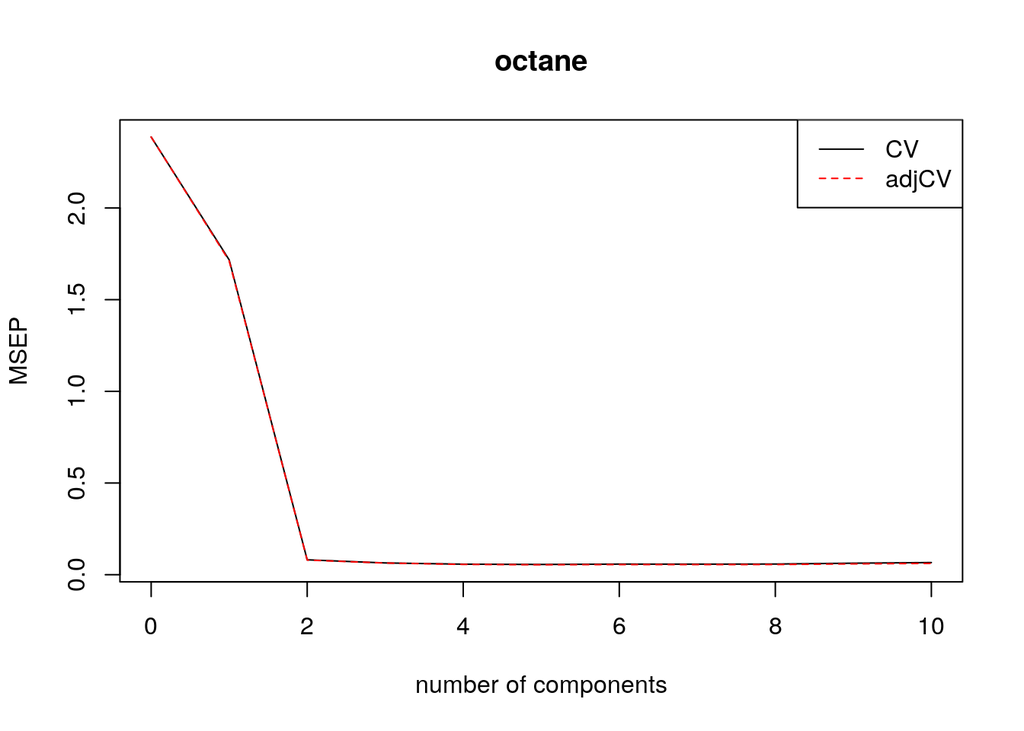

```r
###################################################
gas2.cv <- crossval(gas2, segments = 10)
plot(MSEP(gas2.cv), legendpos='topright')
```

```r
summary(gas2.cv, what = "validation")
```

```
## Data:    X dimension: 50 401
##  Y dimension: 50 1
## Fit method: kernelpls
## Number of components considered: 10
##
## VALIDATION: RMSEP
## Cross-validated using 10 random segments.
##        (Intercept)  1 comps  2 comps  3 comps  4 comps  5 comps  6 comps
## CV           1.545    1.310   0.2851   0.2535   0.2398   0.2366   0.2406
## adjCV        1.545    1.308   0.2827   0.2523   0.2367   0.2330   0.2352
##        7 comps  8 comps  9 comps  10 comps
## CV      0.2400   0.2413   0.2508    0.2575
## adjCV   0.2348   0.2354   0.2430    0.2485
```

Tutaj za to wyniki różnią się o +/- kilka tysięcznych. Znowu jest to winą innego seeda, gdyż tutaj jest kroswalidacja przy uzyciu losowych segmentów.

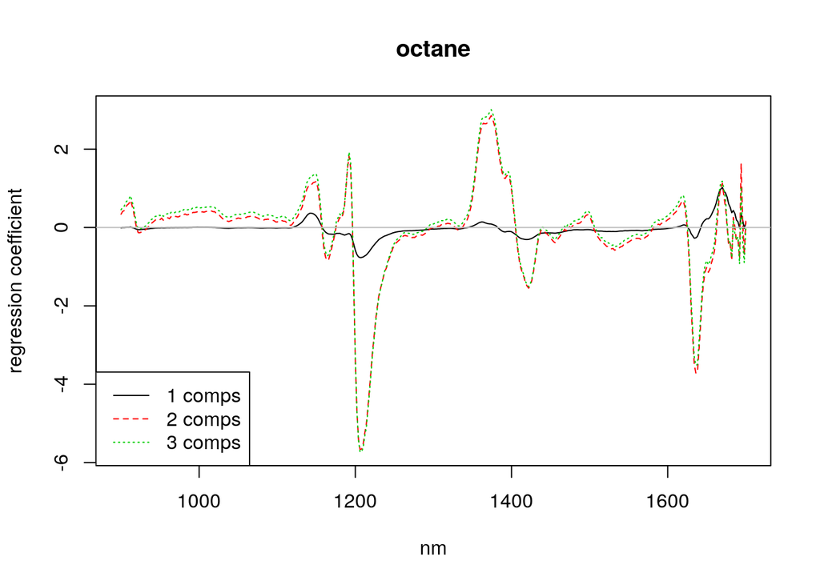

```r
###################################################
plot(gas1, plottype = "coef", ncomp=1:3, legendpos = "bottomleft", labels = "numbers", xlab = "nm")
```

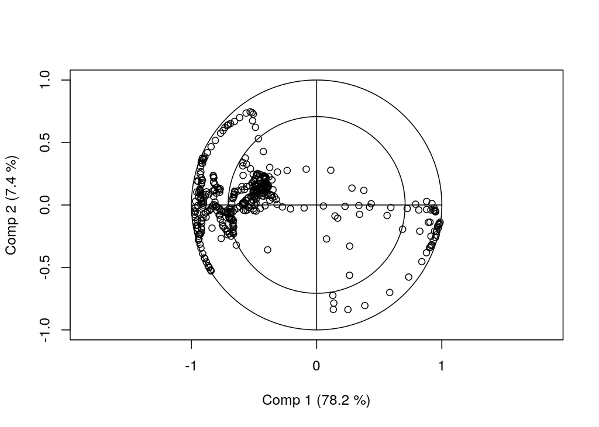

```r
###################################################
plot(gas1, plottype = "correlation")
```

```r
###################################################
predict(gas1, ncomp = 2:3, newdata = gasTest[1:5,])
```

```
## , , 2 comps
##
##      octane
## 51 87.94125
## 52 87.25242
## 53 88.15832
## 54 84.96913
## 55 85.15396
##
## , , 3 comps
##
##      octane
## 51 87.94907
## 52 87.30484
## 53 88.21420
## 54 84.86945
## 55 85.24244
```

Tutaj znowu zaokrąglenia do piątej liczby po przecinku, kiedy w artykule jest do drugiej.

```r
###################################################
predict(gas1, comps = 2, newdata = gasTest[1:5,])
```

```
##      octane
## 51 87.53322
## 52 86.30322
## 53 87.35217
## 54 85.81561
## 55 85.31952
```

Tak samo jak wyżej.

```r
###################################################
drop(predict(gas1, ncomp = 2:3, newdata = gasTest[1:5,]))
```

```
##     2 comps  3 comps
## 51 87.94125 87.94907
## 52 87.25242 87.30484
## 53 88.15832 88.21420
## 54 84.96913 84.86945
## 55 85.15396 85.24244
```

Jak wyżej.

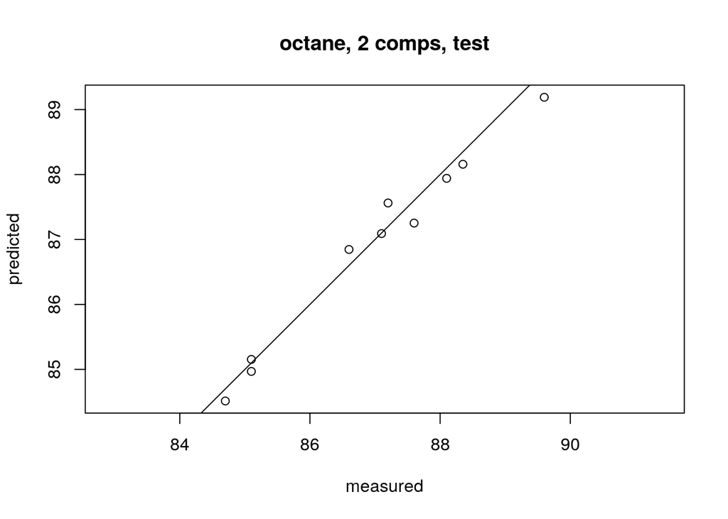

```r
###################################################
predplot(gas1, ncomp = 2, newdata = gasTest, asp = 1, line = TRUE)
```

```r
###################################################
pls.options()
```

```
## $mvralg
## [1] "kernelpls"
##
## $plsralg
## [1] "kernelpls"
##
## $cpplsalg
## [1] "cppls"
##
## $pcralg
## [1] "svdpc"
##
## $parallel
## NULL
##
## $w.tol
## [1] 2.220446e-16
##
## $X.tol
## [1] 1e-12
```

```r
###################################################
pls.options(plsralg = "oscorespls")
```

```r
###################################################
pls.options("plsralg")
```

```
## $plsralg
## [1] "oscorespls"
```

```r
rm(.pls.Options)
pls.options("plsralg")
```

```
## $plsralg
## [1] "oscorespls"
```

Tutaj tak samo `$plsralg` powinno mieć wartość `"kernelpls"`.

```r
###################################################
X <- gasTrain$NIR
Y <- gasTrain$octane
ncomp <- 5
cvPreds <- matrix(nrow = nrow(X), ncol = ncomp)
for (i in 1:nrow(X)) {
    fit <- simpls.fit(X[-i,], Y[-i], ncomp = ncomp, stripped = TRUE)
    cvPreds[i,] <- (X[i,] - fit$Xmeans) %*% drop(fit$coefficients) + fit$Ymeans
}
```

```r
###################################################
sqrt(colMeans((cvPreds - Y)^2))
```

```
## [1] 1.3569509 0.2966201 0.2524084 0.2475784 0.2397937
```

Tak samo jak wcześniej tutaj zaokrąglenia do siódmej liczby a nie jak w artykule do czwartej.

### 5.2.1 Podsumowanie

Artykuł jest bardzo reprodukowalny. Wyniki są praktycznie takie same, różnią się jedynie w przypadku bardziej dokładnych rozwinięć i losowo wybranych obiektów, prawdopodobnie przez innego seeda. Widać też że pakiet ten został od zamieszczenia go rozwinięty.

# 6 Empirical Mode Decomposition and Hilbert Spectrum

Ten artykuł (Donghoh i Hee-Seok, 2009) dotyczy pakietu [`EMD`](https://cran.r-project.org/web/packages/EMD/index.html) służącego do dekompozycji sygnału na tzw. intrinsic mode function (funkcja trybu wewnętrznego).

Link do artykułu: [`https://doi.org/10.32614/RJ-2009-002`](https://doi.org/10.32614/RJ-2009-002)

## 6.1 Intrinsic mode function

### 6.1.1 Przygotowanie danych

```r
ndata <- 3000
tt <- seq(0, 9, length=ndata)
xt <- sin(pi * tt)
```

### 6.1.2 Wywołanie funkcji

```r
library(EMD)
extrema(xt)
```

```
## $minindex
##      [,1] [,2]
## [1,]  501  501
## [2,] 1167 1167
## [3,] 1834 1834
## [4,] 2500 2500
##
## $maxindex
##      [,1] [,2]
## [1,]  168  168
## [2,]  834  834
## [3,] 1500 1501
## [4,] 2167 2167
## [5,] 2833 2833
##
## $nextreme
## [1] 9
##
## $cross
##       [,1] [,2]
##  [1,]    1    1
##  [2,]  334  335
##  [3,]  667  668
##  [4,] 1000 1001
##  [5,] 1333 1334
##  [6,] 1667 1668
##  [7,] 2000 2001
##  [8,] 2333 2334
##  [9,] 2666 2667
##
## $ncross
## [1] 9
```

Nie było problemów z reprodukcją tego fragmentu.

### 6.1.3 Przesiewanie

### 6.1.4 Przygotowanie danych

```r
ndata <- 3000
par(mfrow=c(1,1), mar=c(1,1,1,1))
tt2 <- seq(0, 9, length=ndata)
xt2 <- sin(pi * tt2) + sin(2* pi * tt2) + sin(6 * pi * tt2)  + 0.5 * tt2
```

## 6.2 Rezultaty

```r
plot(tt2, xt2, xlab="", ylab="", type="l", axes=FALSE); box()
tryimf <- extractimf(xt2, tt2, check=TRUE)
```

Ta część nie jest w pełni odtwarzalna. Nie byliśmy w stanie zarejestrować wszystkich etapów procesu przesiewania. Różnił się on również od oryginału.

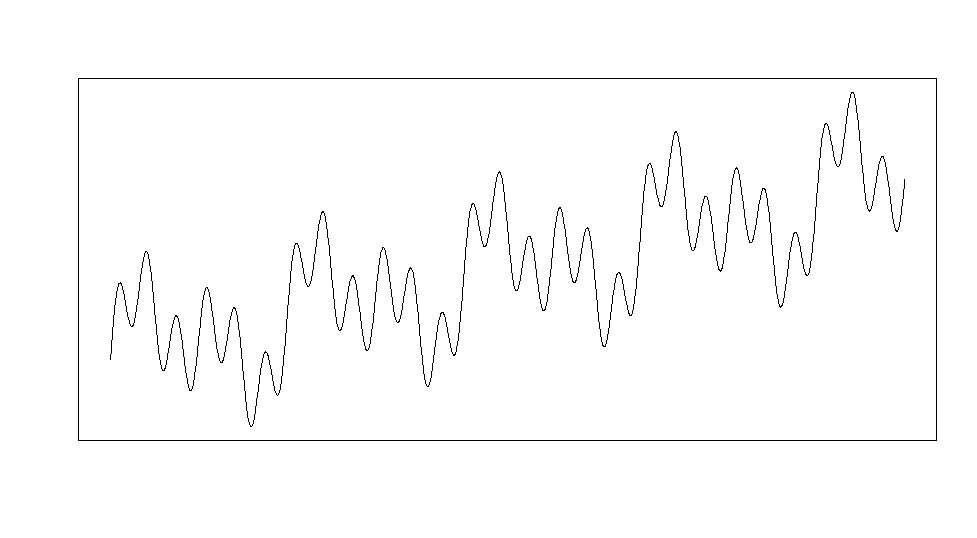

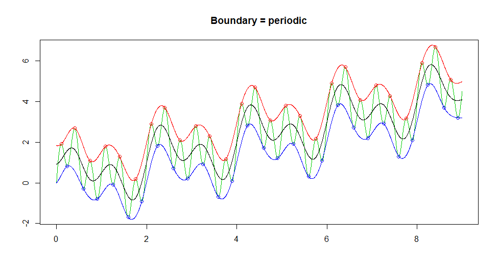

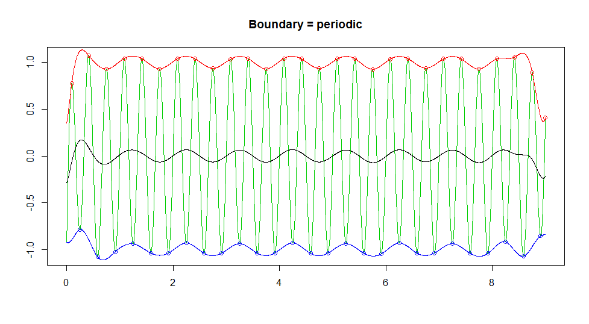

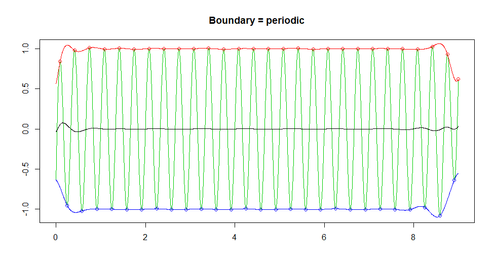

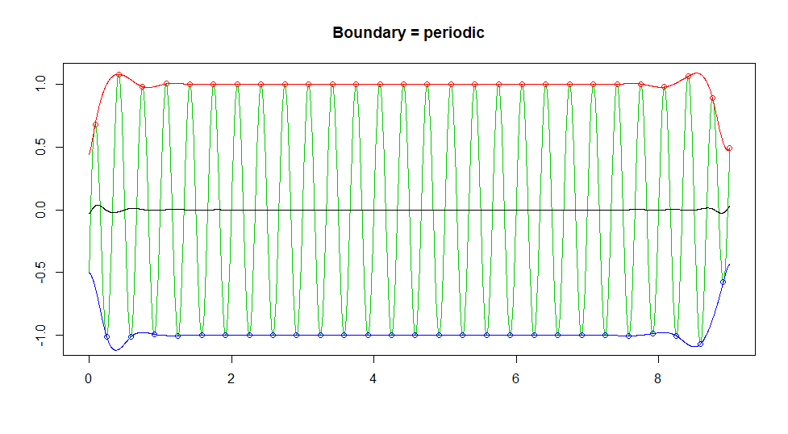

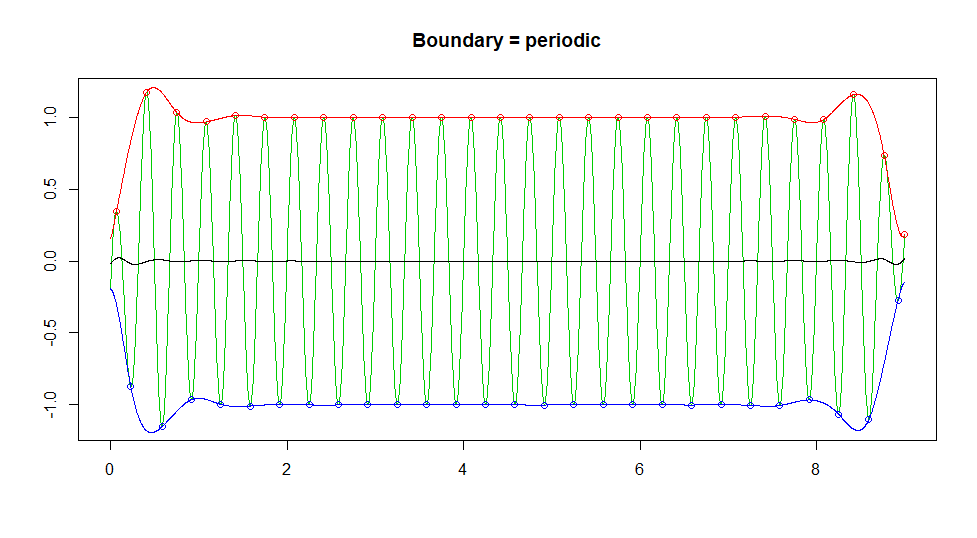

## 6.3 Empirical mode decomposition

### 6.3.1 Wywołanie funkcji

```r
par(mfrow=c(3,1), mar=c(2,1,2,1))
try <- emd(xt2, tt2, boundary="wave")
```

### 6.3.2 Wykres IMF

To było bardzo proste zadanie, które zostało całkowicie odtworzone.

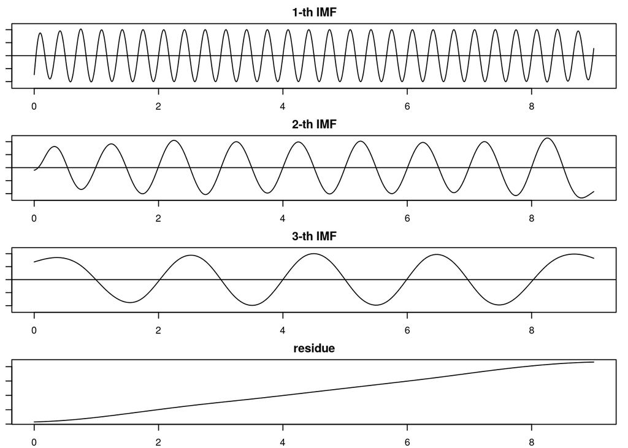

```r
par(mfrow=c(3,1), mar=c(2,1,2,1))
par(mfrow=c(try$nimf+1, 1), mar=c(2,1,2,1))
rangeimf <- range(try$imf)
for(i in 1:try$nimf){
  plot(tt2, try$imf[,i], type="l", xlab="", ylab="",
       ylim=rangeimf, main= paste(i, "-th IMF", sep=""));
  abline(h=0)
}
plot(tt2, try$residue, xlab="", ylab="", main="residue", type="l")
```

## 6.4 Okresowość

### 6.4.1 Mode mixing

Ta część również daje te same wyniki co w oryginalnym artykule.

```r
tt <- seq(0, 0.1, length = 2001)[1:2000]
f1 <- 1776; f2 <- 1000
xt <- sin(2*pi*f1*tt) * (tt <= 0.033 | tt >= 0.067) + sin(2*pi*f2*tt)
```

## 6.5 EMD

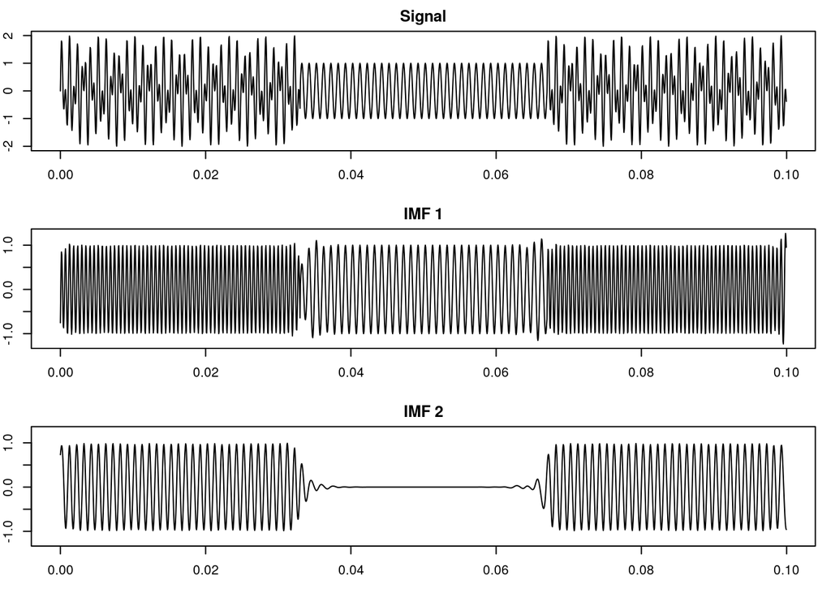

```r
interm1 <- emd(xt, tt, boundary="wave", max.imf=2, plot.imf=FALSE)
par(mfrow=c(3, 1), mar=c(3,2,2,1))
plot(tt, xt, main="Signal", type="l")
rangeimf <- range(interm1$imf)
plot(tt, interm1$imf[,1], type="l", xlab="", ylab="", ylim=rangeimf, main="IMF 1")
plot(tt, interm1$imf[,2], type="l", xlab="", ylab="", ylim=rangeimf, main="IMF 2")
```

## 6.6 Histogram of empirical period

Histogram został poprawnie odtworzony.

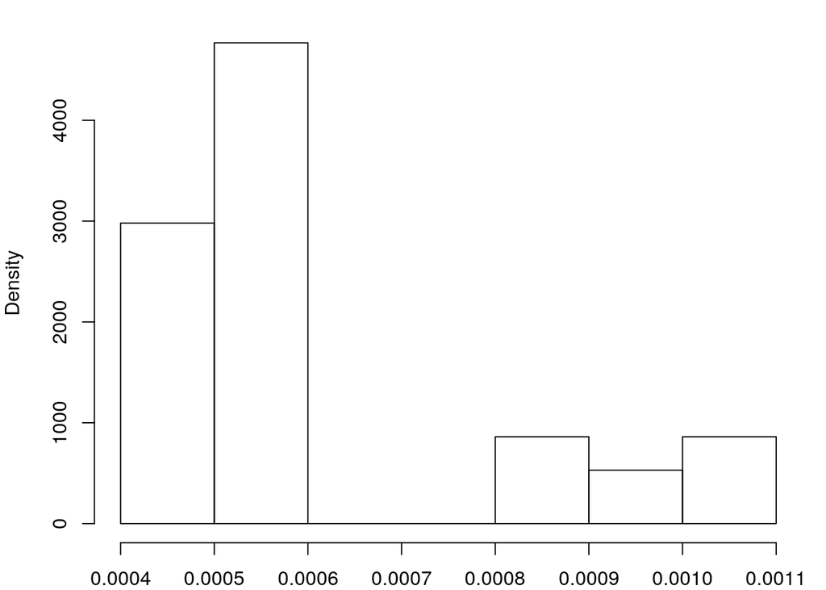

```r
par(mfrow=c(1,1), mar=c(2,4,1,1))
tmpinterm <- extrema(interm1$imf[,1])
zerocross <- as.numeric(round(apply(tmpinterm$cross, 1, mean)))
hist(diff(tt[zerocross[seq(1, length(zerocross), by=2)]]), freq=FALSE, xlab="", main="")
```

## 6.7 Treating intermittence

```r
interm2 <- emd(xt, tt, boundary="wave", max.imf=2, plot.imf=FALSE, interm=0.0007)
```

## 6.8 Wykres każdego IMF

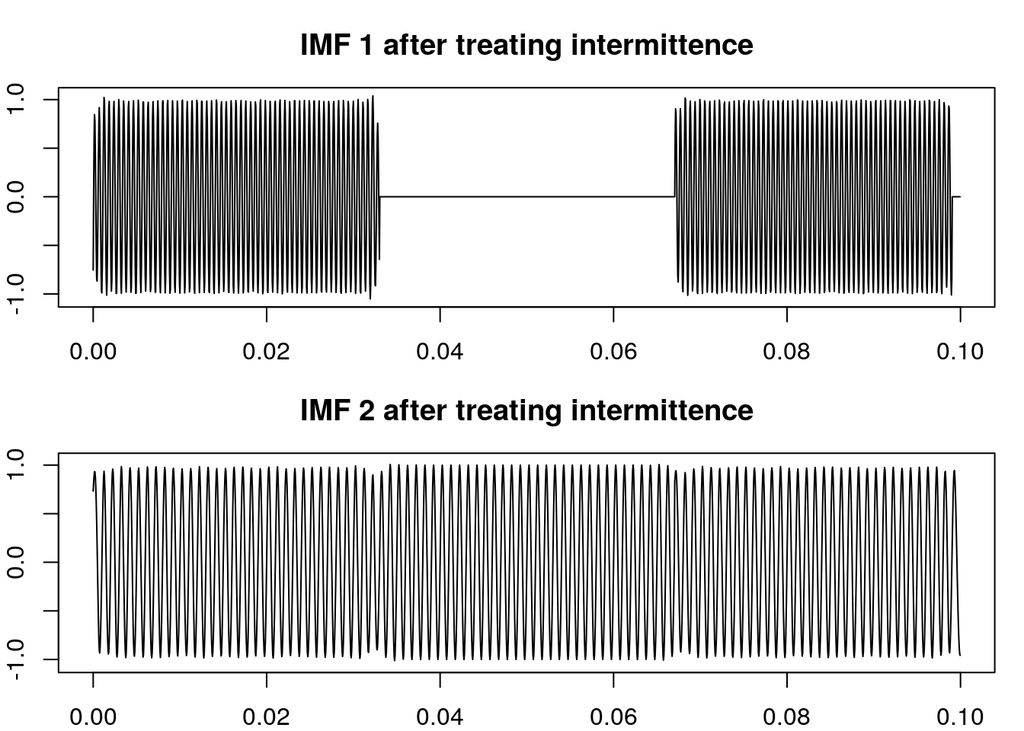

```r
par(mfrow=c(2,1), mar=c(2,2,3,1), oma=c(0,0,0,0))
rangeimf <- range(interm2$imf)
plot(tt,interm2$imf[,1], type="l", main="IMF 1 after treating intermittence",
     xlab="", ylab="", ylim=rangeimf)
plot(tt,interm2$imf[,2], type="l", main="IMF 2 after treating intermittence",
     xlab="", ylab="", ylim=rangeimf)
```

## 6.9 Spektrum Hilberta

Oba spektrogramy zostały odtworzone bez problemów, ale są mało widoczne.

## 6.10 First Spectrogram

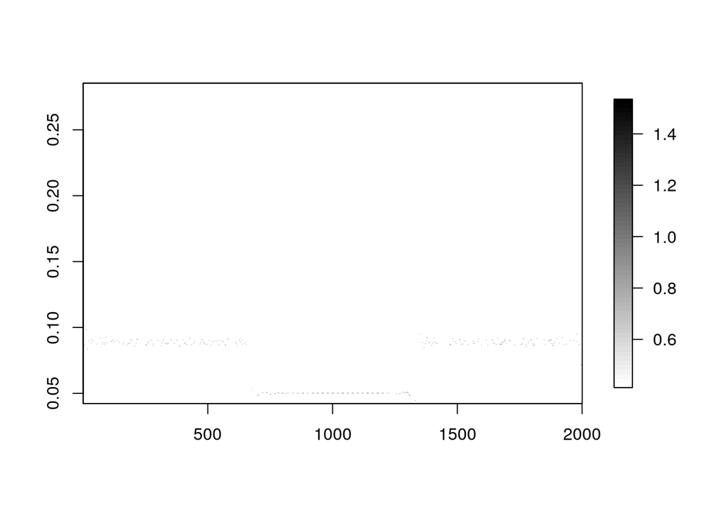

```r
test1 <- hilbertspec(interm1$imf)
spectrogram(test1$amplitude[,1], test1$instantfreq[,1])
```

## 6.11 Drugi spektrogram

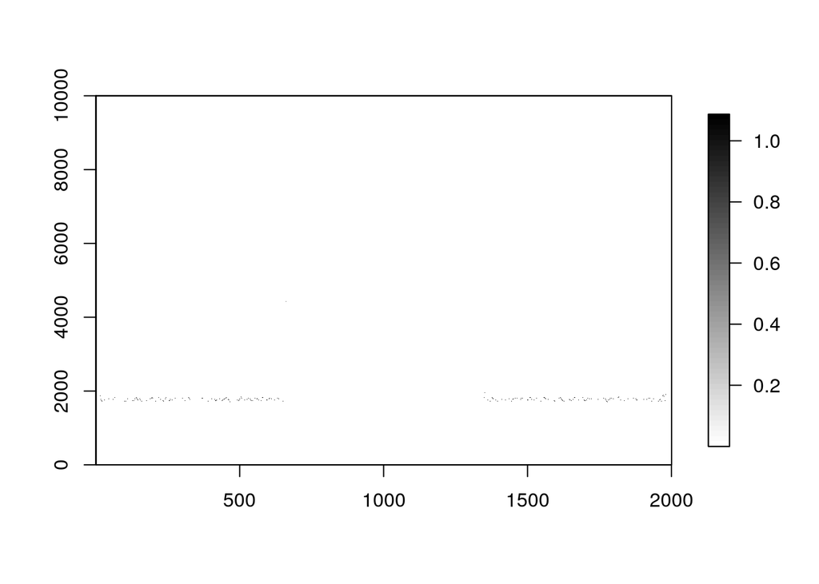

```r
test2 <- hilbertspec(interm2$imf, tt=tt)
spectrogram(test2$amplitude[,1], test2$instantfreq[,1])
```

## 6.12 Extension to two dimensional image

## 6.13 Wczytywanie danych i rozkład

```r
data(lena)
z <- lena[seq(1, 512, by=4), seq(1, 512, by=8)]
```

Przetworzenie tej części zajmuje najwięcej czasu. Dlatego postanowiliśmy zmniejszyć rozmiar zdjęcia jeszcze bardziej niż autorzy artykułu.

```r
lenadecom <- emd2d(z, max.imf = 4)
```

Ta część jest w pełni odtwarzalna.

## 6.14 Result plot

[figure not shown]

```r
imageEMD(z=z, emdz=lenadecom, extrema=TRUE, col=gray(0:100/100))
```

# 7 AdMit: Adaptive Mixtures of Student-t Distributions

## 7.1 Opis

`AdMit` jest pakietem opisanym w wydaniu [The R Journal](https://journal.r-project.org/archive/2009/RJ-2009-003/index.html) pochodzącym z czerwca 2009 roku. Najnowsza wersja na [CRAN](https://cran.r-project.org/web/packages/AdMit/index.html) została wypuszczona 20 kwietnia 2020, zatem jak najbardziej podchodzi pod kategorię *wciąż aktualizowanych starych pakietów*.  
Autorzy artykułu nie dołączyli dodatkowych źródeł kodu ani skryptów, jednak kod generujący wyniki jest podany w paragrafach w tekście, tak jak zostałby wpisany do konsoli `R`. Spowodowało to dodatkowe niepotrzebne kopiowanie i formatowanie.

## 7.2 Reprodukcja

```r
# install.packages("AdMit")
library(AdMit)
```

W wersji `R 3.6.3` instalacja odbyła się szybko, bez żadnych komplikacji.  
.  
.  
.

```r
set.seed(1234)
```

To ziarno zostało podane przez autoróœ. Ponieważ jest powszechnie wiadome, że aktualizacja `R 3.6.0` zmieniła sposób działania generatora losowości, więc już teraz można się spodziewać trochę odmiennych wyników.  
.  
.  
.

```r
GelmanMeng <- function(x, log = TRUE) {
    if (is.vector(x)) x <- matrix(x, nrow = 1)
    r <- -0.5 * ( 5 * x[,1]^2 * x[,2]^2 + x[,1]^2 + x[,2]^2 - 10 * x[,1] * x[,2] - 6 * x[,1] - 7 * x[,2] )
    if (!log) r <- exp(r)
    as.vector(r)
}
```

Powyższy kod tworzy jądro (*kernel*), który później jest wizualizowany na wykresach, iestety kod generujący je nie został załączony.  
.  
.  
.

```r
(outAdMit <- AdMit(KERNEL = GelmanMeng, mu0 = c(0, 0.1)))
```

```
## $CV
## [1] 7.8797364 1.7576829 0.9566853 0.8893195
##
## $mit
## $mit$p
##       cmp1       cmp2       cmp3       cmp4
## 0.64051741 0.07157414 0.20844640 0.07946205
##
## $mit$mu
##             k1        k2
## cmp1 0.3639585 3.2002046
## cmp2 3.7088254 0.3175160
## cmp3 1.3855024 1.1625991
## cmp4 2.4625620 0.6313581
##
## $mit$Sigma
##            k1k1        k1k2        k2k1       k2k2
## cmp1 0.03902518 -0.15605612 -0.15605612 1.22561184
## cmp2 0.86080447 -0.08397973 -0.08397973 0.02252490
## cmp3 0.12716098 -0.06816106 -0.06816106 0.10222707
## cmp4 0.21956988 -0.01357107 -0.01357107 0.02490221
##
## $mit$df
## [1] 1
##
##
## $summary
##   H METHOD.mu TIME.mu METHOD.p TIME.p        CV
## 1 1      BFGS   0.020     NONE  0.000 7.8797364
## 2 2      BFGS   0.010   NLMINB  0.016 1.7576829
## 3 3      BFGS   0.039   NLMINB  0.008 0.9566853
## 4 4      BFGS   0.040   NLMINB  0.017 0.8893195
```

```r
(outAdMitIS <- AdMitIS(N = 1e5, KERNEL = GelmanMeng, mit = outAdMit$mit))
```

```
## $ghat
## [1] 0.9679769 2.2285986
##
## $NSE
## [1] 0.003747675 0.005276410
##
## $RNE
## [1] 0.6440028 0.6318012
```

Wyniki są z reguły trochę różne od oryginalnych, najprawdopodobniej głównie z powodu innego generatora liczb losowych. Ponadto można zauważyć, że stosowana jest inna metoda zaokrąglania liczb.  
.  
.  
.

```r
(outAdMitMH <- AdMitMH(N = 101000, KERNEL = GelmanMeng, mit = outAdMit$mit))
```

Ten kod w `markdown` generuje $50000$ linijek wyników i z dumą oświadcza, że pominął kolejne $50000$, jednak w samym `R` generują się one w przystępny sposób.  
.  
.  
Na potrzeby tego artykułu trzeba było przepisać tę linijkę kodu.

```r
# rewritten upper chunk
head(outAdMitMH$draws, 7)
```

```
##          k1         k2
## 1 0.9095752 -2.2127290
## 2 0.6661026  1.1082125
## 3 2.2159885  0.7770256
## 4 0.2783000  3.3669236
## 5 0.2783000  3.3669236
## 6 0.1393632  4.0439795
## 7 1.1690606  0.8822938
```

```r
outAdMitMH$accept
```

```
## [1] 0.5061188
```

Tutaj ponownie wyniki są prawie równe oryginalnym.  
.  
.  
.

```r
library("coda")
draws <- as.mcmc(outAdMitMH$draws)
draws <- window(draws, start = 1001)
colnames(draws) <- c("X1", "X2")
summary(draws)$stat
```

```
##         Mean        SD    Naive SE Time-series SE
## X1 0.9601571 0.9430263 0.002982111    0.005108426
## X2 2.2440007 1.3290242 0.004202743    0.007185532
```

```r
effectiveSize(draws) / niter(draws)
```

```
##        X1        X2
## 0.3407794 0.3420960
```

W tym miejscu wprowadzony został pakiet `coda`, w celu sprawdzenia osiągów `AdMit`. Szczęśliwie również i on zainstalował się i działał bez komplikacji, a wyniki prawie wyglądają jak te oryginalne.

## 7.3 Podsumowanie

Podsumowując, `AdMit` jest przykładem *wciąż aktualizowanego starego pakietu*, którego działanie różni się trochę od wersji z 2009 roku, ale mówiąc ogólnie - wciąż działa tak, jak było to zamierzone.

# 8 Wnioski

- Nastąpiła zmiana seeda, co przeszkadza w dokładnej reprodukcji;
- Zdarza się, że zbiory danych są już niedostępne;
- Mogły nastąpić zmiany nazw.

Jendak ogólnie mówiąc, jest to możliwe do zreprodukowania przy niewielkim nakładzie pracy i zrozumieniu działania kodu.